# Predicting Body Weight Based on Lifestyle and Demographic Factors

Evan Yuan

2026-10-10

# 1. INTRODUCTION

## 1.1 Background

Obesity has become a global health epidemic, with obesity rates nearly tripling worldwide since 1975 according to the World Obesity Federation. Understanding the factors that contribute to body weight is crucial for developing effective public health interventions. This study analyzes data collected from 2,111 individuals across Mexico, Peru, and Colombia to model and predict body weight based on various lifestyle, demographic, and behavioral factors.

Our dataset, sourced from the UCI Machine Learning Repository, contains comprehensive information about individuals’ physical characteristics, dietary habits, and activity levels. Each observation represents a single person and includes 17 variables capturing various aspects of their lifestyle. Our primary goal is to develop a linear regression model that can accurately predict body weight using both quantitative predictors (such as age and height) and categorical predictors (such as gender and family history).

Our analysis will explore how factors including physical activity frequency, water consumption, eating habits, and transportation methods relate to body weight. By identifying significant predictors and their relationships with weight, this study aims to provide insights that could inform both individual health decisions and broader public health strategies.

## 1.2 Dataset Description

- **Source**: UCI Machine Learning Repository - Estimation of Obesity Levels Based on Eating Habits and Physical Condition
- **Observations**: 2,111 individuals from Mexico, Peru, and Colombia
- **Response Variable**: Weight (kg) - continuous quantitative variable
- **Predictors**: Age, Height, Gender, family history, eating habits (FAVC, FCVC, NCP), smoking (SMOKE), water consumption (CH2O), calorie monitoring (SCC), physical activity (FAF), technology use (TUE), CAEC (eating between meals), CALC (alcohol), and MTRANS (transportation)

# 2. METHODS

## 2.1 Data Cleaning

```
## No missing values detected in the dataset.
```

```
## Number of duplicate rows: 24
```

```
## Removing 24 duplicate rows...
## Rows after removing duplicates: 2087
```

The data cleaning process revealed no missing values in our dataset of 2,087 observations. All categorical variables were properly converted to factors for appropriate handling in our regression models. All duplicate values were removed.

## 2.2 Exploratory Data Analysis (EDA)

```
##       Age            Height          Weight            FCVC
##  Min.   :14.00   Min.   :1.450   Min.   : 39.00   Min.   :1.000
##  1st Qu.:19.92   1st Qu.:1.630   1st Qu.: 66.00   1st Qu.:2.000
##  Median :22.85   Median :1.702   Median : 83.10   Median :2.396
##  Mean   :24.35   Mean   :1.703   Mean   : 86.86   Mean   :2.421
##  3rd Qu.:26.00   3rd Qu.:1.769   3rd Qu.:108.02   3rd Qu.:3.000
##  Max.   :61.00   Max.   :1.980   Max.   :173.00   Max.   :3.000
##       NCP             CH2O            FAF              TUE
##  Min.   :1.000   Min.   :1.000   Min.   :0.0000   Min.   :0.0000
##  1st Qu.:2.697   1st Qu.:1.591   1st Qu.:0.1245   1st Qu.:0.0000
##  Median :3.000   Median :2.000   Median :1.0000   Median :0.6309
##  Mean   :2.701   Mean   :2.005   Mean   :1.0128   Mean   :0.6630
##  3rd Qu.:3.000   3rd Qu.:2.466   3rd Qu.:1.6781   3rd Qu.:1.0000
##  Max.   :4.000   Max.   :3.000   Max.   :3.0000   Max.   :2.0000
```

```
##
## Insufficient_Weight       Normal_Weight      Obesity_Type_I
##                 267                 282                 351
##     Obesity_Type_II    Obesity_Type_III  Overweight_Level_I
##                 297                 324                 276
## Overweight_Level_II
##                 290
```

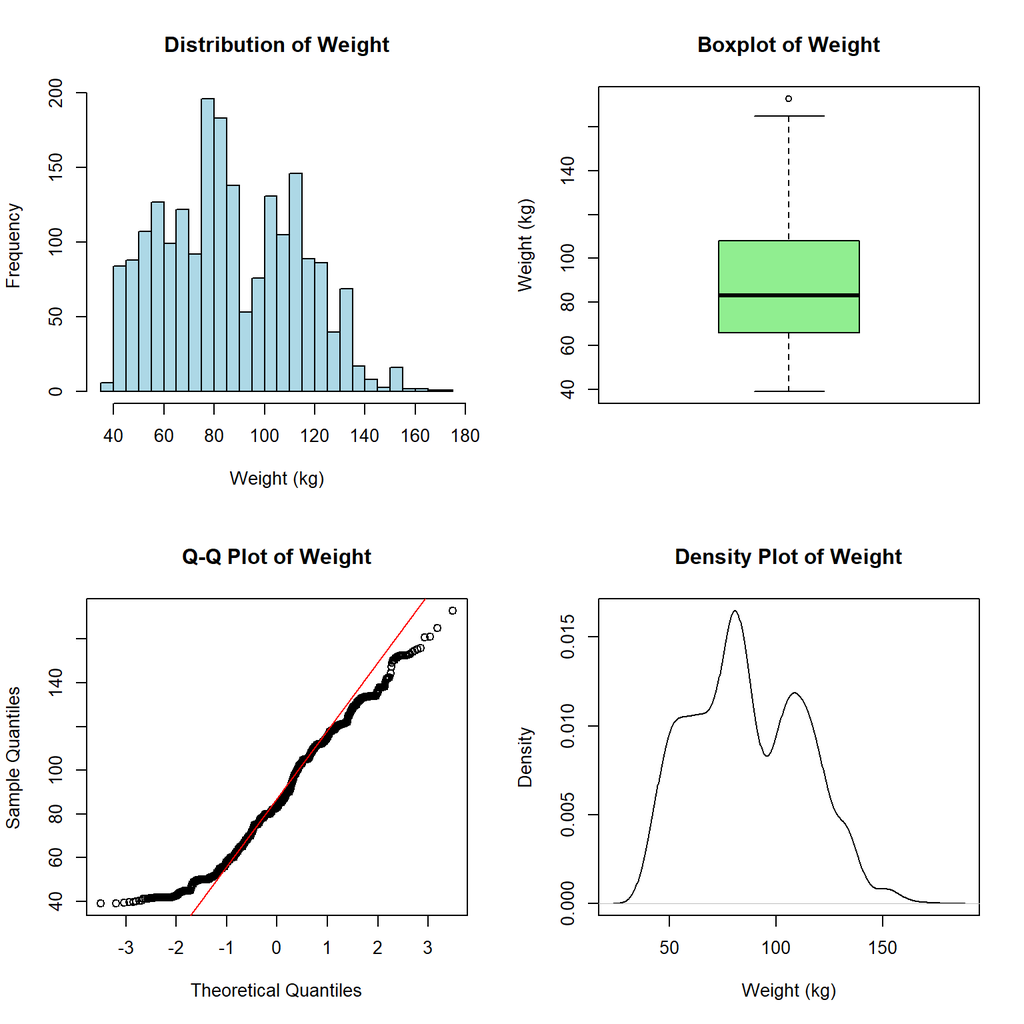

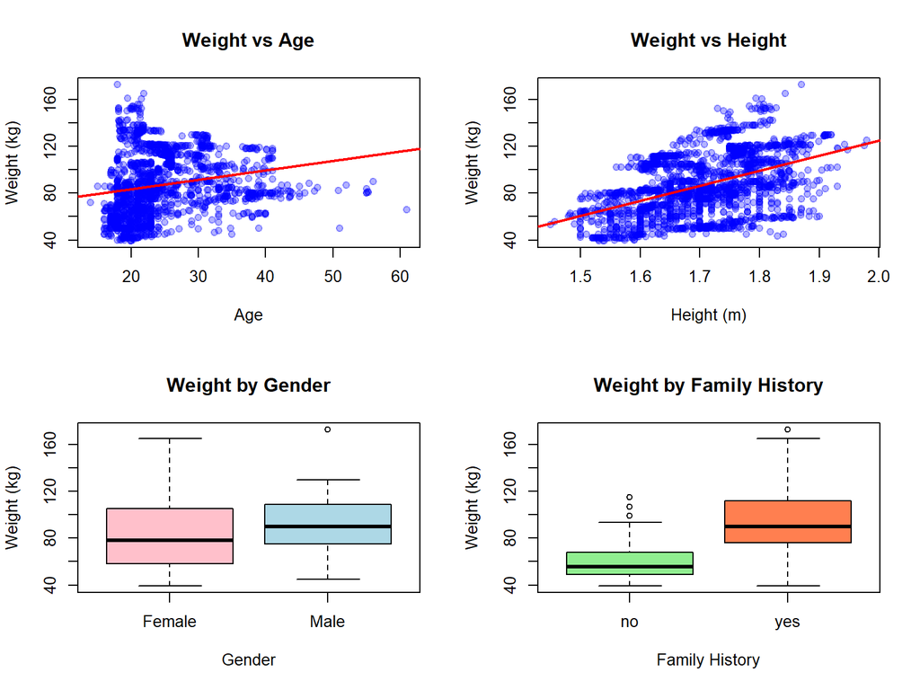

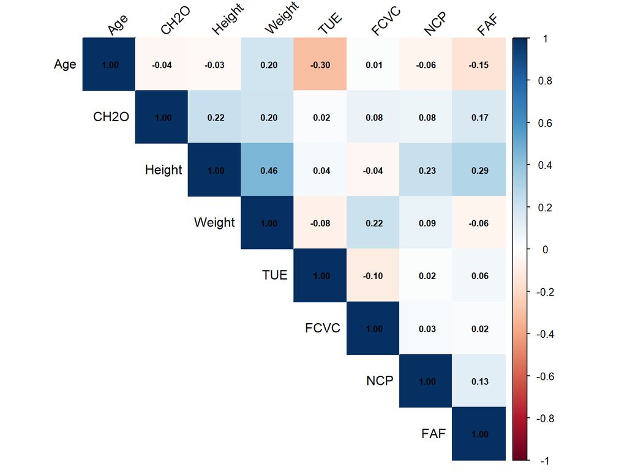

## 2.3 Initial Full Linear Model

```
##
## Call:
## lm(formula = Weight ~ . - NObeyesdad, data = obesity)
##
## Residuals:
##     Min      1Q  Median      3Q     Max
## -54.402 -12.009   1.453  10.423  78.626
##
## Coefficients:
##                                     Estimate Std. Error t value
## (Intercept)                       -193.98452   19.84114  -9.777
## GenderMale                          -4.50309    1.03911  -4.334
## Age                                  0.96844    0.08089  11.972
## Height                             123.17361    5.95264  20.692
## family_history_with_overweightyes   18.10795    1.11988  16.170
## FAVCyes                              4.58561    1.27390   3.600
## FCVC                                 8.79018    0.75133  11.699
## NCP                                  0.52983    0.51261   1.034
## CAECFrequently                      -9.31993    2.61909  -3.558
## CAECno                               4.77954    3.72217   1.284
## CAECSometimes                        9.87700    2.42134   4.079
## SMOKEyes                            -0.67575    2.65232  -0.255
## CH2O                                 1.62481    0.65578   2.478
## SCCyes                              -4.90176    1.87924  -2.608
## FAF                                 -2.52326    0.48681  -5.183
## TUE                                 -1.33177    0.66448  -2.004
## CALCFrequently                     -11.92271   17.39806  -0.685
## CALCno                             -14.47612   17.29010  -0.837
## CALCSometimes                       -7.33806   17.30367  -0.424
## MTRANSBike                           5.09961    6.55557   0.778
## MTRANSMotorbike                     12.33709    5.27086   2.341
## MTRANSPublic_Transportation         14.22821    1.17708  12.088
## MTRANSWalking                        4.20865    2.60691   1.614
##                                   Pr(>|t|)
## (Intercept)                        < 2e-16 ***
## GenderMale                        1.54e-05 ***
## Age                                < 2e-16 ***
## Height                             < 2e-16 ***
## family_history_with_overweightyes  < 2e-16 ***
## FAVCyes                           0.000326 ***
```

[output cut: 8 more lines]

```
## FAF                               2.39e-07 ***
## TUE                               0.045175 *
## CALCFrequently                    0.493238
## CALCno                            0.402550
## CALCSometimes                     0.671555
## MTRANSBike                        0.436714
## MTRANSMotorbike                   0.019346 *
## MTRANSPublic_Transportation        < 2e-16 ***
## MTRANSWalking                     0.106590
## ---
## Signif. codes:  0 '***' 0.001 '**' 0.01 '*' 0.05 '.' 0.1 ' ' 1
##
## Residual standard error: 17.03 on 2064 degrees of freedom
## Multiple R-squared:  0.5816, Adjusted R-squared:  0.5771
## F-statistic: 130.4 on 22 and 2064 DF,  p-value: < 2.2e-16
```

### Model Interpretation

The initial full model includes all available predictors except the obesity category variable (NObeyesdad), which is directly derived from weight and BMI, making it inappropriate as a predictor. Weight (kg) is the response variable.

**Coefficient Interpretation:**

**Quantitative Predictors:**

- **Height**: Height has the strongest association with weight. A one-meter increase in height is associated with an average increase of approximately 123 kg in weight.
- **Age**: Age is positively associated with weight. A one-year increase in age corresponds to an average increase of approximately 0.97 kg in weight.
- **Physical Activity Frequency (FAF)**: Significantly negatively associated with weight. Each one-unit increase in physical activity frequency corresponds to an average decrease of 2.52 kg in weight.
- **Daily Water Consumption (CH2O)**: Shows a small but statistically significant positive association (1.62 kg per unit), suggesting that water intake alone does not strongly differentiate body weight once other behaviors are accounted for.

**Categorical Predictors:**

- **Gender (Male)**: Males weigh on average 4.5 kg less than females when all other factors are held constant, contrary to typical population patterns, possibly due to other confounding factors in this dataset.
- **Family History of Overweight**: Individuals with a family history of overweight weigh approximately 18.11 kg more on average than those without such history, highlighting the strong influence of genetic and environmental factors.
- **Frequent Consumption of High-Calorie Foods (FAVC)**: Associated with a 4.59 kg increase in weight compared to those who don’t frequently consume high-calorie foods.
- **Transportation Mode**:
  - Public transportation users weigh approximately 14.23 kg more than automobile users
  - Motorbike users weigh about 12.34 kg more than automobile users
  - Walking shows a non-significant increase of 4.21 kg compared to automobile use

**R-squared Interpretation:**

The R-squared value of 0.5816 indicates that approximately 58.16% of the variation in weight can be explained by the predictors in our model. The adjusted R-squared is 0.5771, which we will use as a baseline for model comparison. The small difference between R-squared and adjusted R-squared suggests that, despite the large number of predictors, the model is not overly inflated by unnecessary variables.

### Model Diagnostics

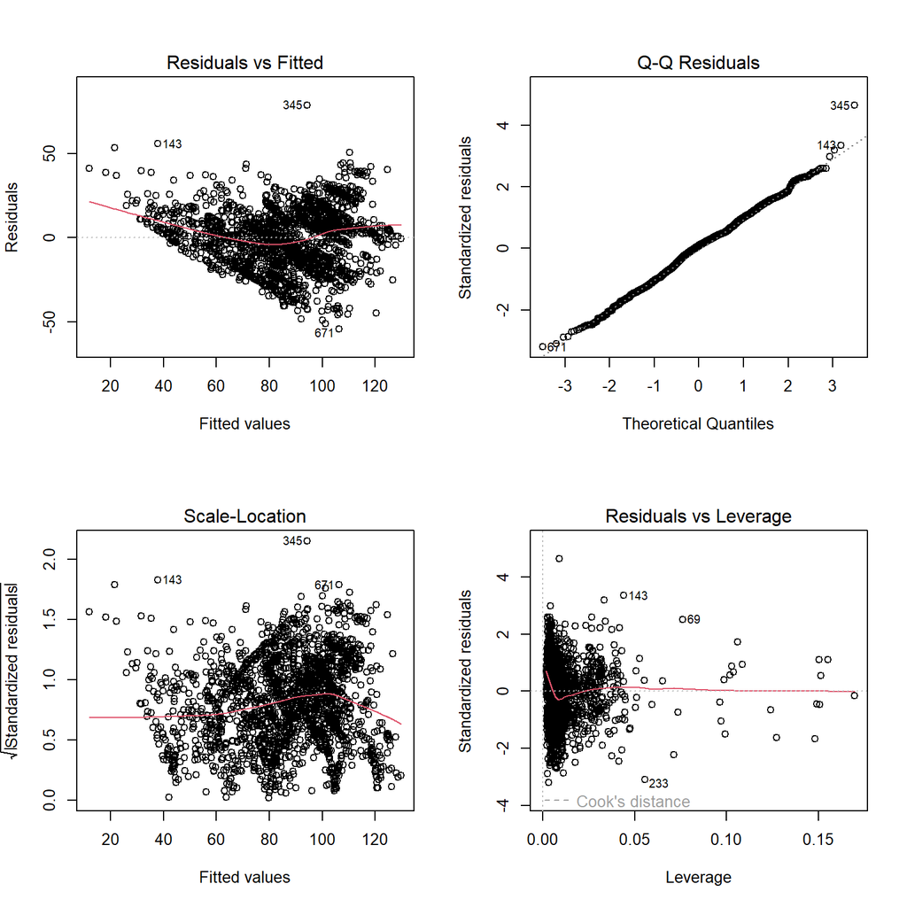

```
## [1] "Variance Inflation Factors:"
```

```
##  [1] 4.000000 3.000000 3.000000 2.212661 1.941953 1.908563 1.893853
##  [8] 1.487502 1.393540 1.381507
```

```
##
## Shapiro-Wilk test p-value: 4.871521e-05
```

```
## Breusch-Pagan test p-value: 1.175803e-53
```

### Cross-Validation

| Model | CV_RMSE | CV_R_squared | CV_MAE |
| --- | --- | --- | --- |
| Full Model | 17.11762 | 0.5732762 | 13.60475 |

## 2.4 Model Improvement Methods

### Variable Selection Using Stepwise Methods

| Model | CV_RMSE | CV_R_squared | CV_MAE |
| --- | --- | --- | --- |
| Backward AIC | 17.1283 | 0.5741715 | 13.63747 |

| Model | CV_RMSE | CV_R_squared | CV_MAE |
| --- | --- | --- | --- |
| Forward AIC | 17.09096 | 0.5747511 | 13.60911 |

| Model | CV_RMSE | CV_R_squared | CV_MAE |
| --- | --- | --- | --- |
| Both-direction AIC | 17.12083 | 0.574863 | 13.63512 |

| Model | CV_RMSE | CV_R_squared | CV_MAE |
| --- | --- | --- | --- |
| Backward BIC | 17.13498 | 0.5723123 | 13.67278 |

```
## Model Comparison - Adjusted R-squared:
```

```
## Full Model: 0.5771166
```

```
## Backward AIC: 0.5772936
```

```
## Forward AIC: 0.5772936
```

```
## Backward BIC: 0.5744975
```

|  | Res.Df | RSS | Df | Sum of Sq | F | Pr(>F) |
| --- | --- | --- | --- | --- | --- | --- |
| 1 | 2069 | 603895.4 | NA | NA | NA | NA |
| 2 | 2066 | 599057.2 | 3 | 4838.2395 | 5.5596364 | 0.0008476377 |
| 3 | 2064 | 598727.8 | 2 | 329.3904 | 0.5677553 | 0.5668847858 |

Variable selection using stepwise methods showed minimal improvement in predictive performance. AIC-based stepwise selection (backward, forward, and both directions) retained most predictors from the full model. BIC-based selection removed several predictors. Removing predictors did not meaningfully improve model fit. The variable selection models all had RMSE around 17.1 kg.

### Polynomial Transformations

```
## [1] 0.5933315
```

|  | Res.Df | RSS | Df | Sum of Sq | F | Pr(>F) |
| --- | --- | --- | --- | --- | --- | --- |
| 1 | 2066 | 599057.2 | NA | NA | NA | NA |
| 2 | 2063 | 597512.1 | 3 | 1545.053 | 1.778175 | 0.149236 |

| Model | CV_RMSE | CV_R_squared | CV_MAE |
| --- | --- | --- | --- |
| Polynomial | 16.78698 | 0.5902946 | 13.18181 |

Adding quadratic terms for Height, Age, and Physical Activity (FAF) increased adjusted R squared to approximately 0.593, representing a noticeable improvement over the initial linear model.

### Interaction Terms

```
## Adjusted R-squared with interactions:
```

```
## Height * Gender: 0.5913179
```

```
## Age * Family History: 0.5775538
```

```
## Height * Age: 0.5844035
```

|  | Res.Df | RSS | Df | Sum of Sq | F | Pr(>F) |
| --- | --- | --- | --- | --- | --- | --- |
| 1 | 2066 | 599057.2 | NA | NA | NA | NA |
| 2 | 2063 | 578341.0 | 3 | 20716.18 | 24.63222 | 1.171591e-15 |

| Model | CV_RMSE | CV_R_squared | CV_MAE |
| --- | --- | --- | --- |
| Height * Gender | 16.84767 | 0.5886097 | 13.62921 |

The Height × Gender interaction improved the model fit from the baseline model and the stepwise models. Allowing the relationship between height and weight to differ by gender meaningfully improves model performance.

### Combined Model: AIC Selection + Interaction

```
## Combined Model Formula:
```

```
## Weight ~ Height * Gender + Age + family_history_with_overweight +
##     FAVC + FCVC + CAEC + CH2O + SCC + FAF + TUE + CALC + MTRANS
```

```
## Adjusted R-squared: 0.5916482
```

```
## Residual Standard Error: 16.73658 kg
```

```
## F-statistic: 144.9209
```

```
## Degrees of Freedom: 22 used, 2065 residual
```

The combined model retains important predictors from AIC selection and includes the best interaction. The combined approach achieves an adjusted R squared of 0.592 and a cross validated RMSE of 16.79 kg.

### Box-Cox Transformation

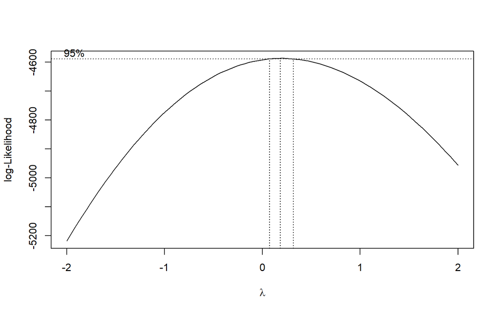

```
## Optimal lambda for Box-Cox transformation: 0.1818182
```

```
## Adjusted R-squared with Box-Cox transformation: 0.5967893
```

The optimal Box-Cox λ is 0.18. The transformed model’s adjusted R² (0.597) is on the transformed scale and isn’t directly comparable to the other models, and it makes coefficients harder to interpret in kg, so we kept Weight untransformed.

|  | intercept | RMSE | Rsquared | MAE | RMSESD | RsquaredSD | MAESD |
| --- | --- | --- | --- | --- | --- | --- | --- |
| 1 | TRUE | 17.11762 | 0.5732762 | 13.60475 | 0.8116383 | 0.0364084 | 0.6415173 |

### Model Comparison

```
##                      Model     RMSE  Rsquared      MAE
## 1 Combined_AIC_Interaction 16.78573 0.5897206 13.56997
## 2               Polynomial 16.80014 0.5910337 13.18147
## 3   Height_Gender_Interact 16.83179 0.5881586 13.60578
## 4             Backward_AIC 17.07558 0.5766074 13.61372
## 5               Full Model 17.11762 0.5732762 13.60475
## 6             Backward_BIC 17.15863 0.5725245 13.69526
```

# 3. CONCLUSION

## 3.1 Final Model Selection

Based on comprehensive model comparison using adjusted R-squared, cross-validation RMSE, and mean absolute error, we select the model that combines AIC backward selection with Height-Gender interaction as our final model.

```
##
## Call:
## lm(formula = Weight ~ Height * Gender + Age + family_history_with_overweight +
##     FAVC + FCVC + CAEC + CH2O + SCC + FAF + TUE + CALC + MTRANS,
##     data = obesity)
##
## Residuals:
##     Min      1Q  Median      3Q     Max
## -55.824 -12.084   2.473  11.195  84.242
##
## Coefficients:
##                                     Estimate Std. Error t value
## (Intercept)                       -270.32741   21.35564 -12.658
## Height                             170.04920    7.86181  21.630
## GenderMale                         149.53909   17.98941   8.313
## Age                                  0.99507    0.07883  12.624
## family_history_with_overweightyes   17.74610    1.10087  16.120
## FAVCyes                              3.86847    1.25123   3.092
## FCVC                                 8.01899    0.74370  10.783
## CAECFrequently                      -9.34332    2.57326  -3.631
## CAECno                               1.27367    3.67193   0.347
## CAECSometimes                        9.39283    2.37728   3.951
## CH2O                                 1.59104    0.64325   2.473
## SCCyes                              -2.88916    1.85966  -1.554
## FAF                                 -2.76140    0.47851  -5.771
## TUE                                 -1.78268    0.65403  -2.726
## CALCFrequently                      -8.46250   17.07705  -0.496
## CALCno                             -10.64099   16.97165  -0.627
## CALCSometimes                       -2.77472   16.98145  -0.163
## MTRANSBike                           3.57402    6.44438   0.555
## MTRANSMotorbike                     10.87355    5.17722   2.100
## MTRANSPublic_Transportation         13.57726    1.15109  11.795
## MTRANSWalking                        4.61102    2.55960   1.801
## Height:GenderMale                  -90.56904   10.55521  -8.581
##                                   Pr(>|t|)
## (Intercept)                        < 2e-16 ***
## Height                             < 2e-16 ***
## GenderMale                         < 2e-16 ***
## Age                                < 2e-16 ***
## family_history_with_overweightyes  < 2e-16 ***
```

[output cut: 8 more lines]

```
## TUE                               0.006471 **
## CALCFrequently                    0.620266
## CALCno                            0.530738
## CALCSometimes                     0.870222
## MTRANSBike                        0.579232
## MTRANSMotorbike                   0.035826 *
## MTRANSPublic_Transportation        < 2e-16 ***
## MTRANSWalking                     0.071776 .
## Height:GenderMale                  < 2e-16 ***
## ---
## Signif. codes:  0 '***' 0.001 '**' 0.01 '*' 0.05 '.' 0.1 ' ' 1
##
## Residual standard error: 16.74 on 2065 degrees of freedom
## Multiple R-squared:  0.5958, Adjusted R-squared:  0.5916
## F-statistic: 144.9 on 21 and 2065 DF,  p-value: < 2.2e-16
```

## 3.2 Final Model Analysis

### Model Performance Metrics

```
## Final Model Performance:
```

```
## R-squared: 0.5957591
```

```
## Adjusted R-squared: 0.5916482
```

```
## Residual Standard Error: 16.73658
```

```
## AIC: 17707.18
```

```
## BIC: 17836.98
```

```
##
## Comparison with Initial Full Model:
```

```
## Initial Adjusted R-squared: 0.5771166
```

```
## Improvement: 0.01453155
```

```
## Initial AIC: 17781.15
```

```
## Initial BIC: 17916.59
```

**Selection Rationale:**

The Combined Model was chosen over alternatives because it produced the lowest cross-validated RMSE (≈16.8 kg), improving slightly upon both the full model and AIC/BIC models. Incorporating the Height × Gender interaction yielded modest gains in predictive performance.

### Final Model Diagnostics

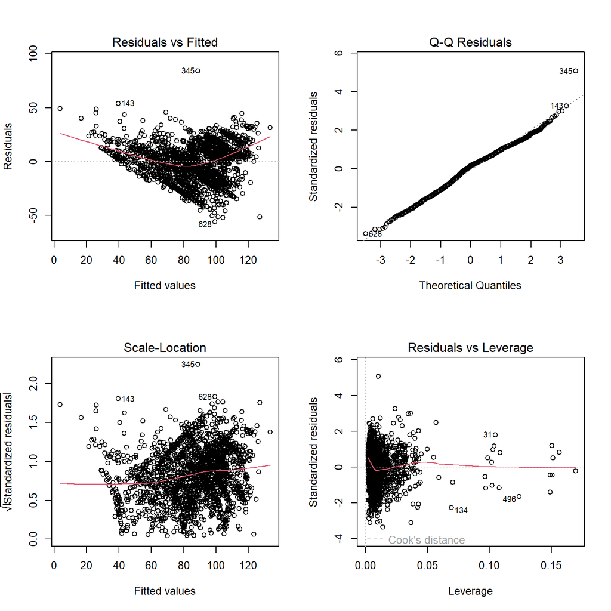

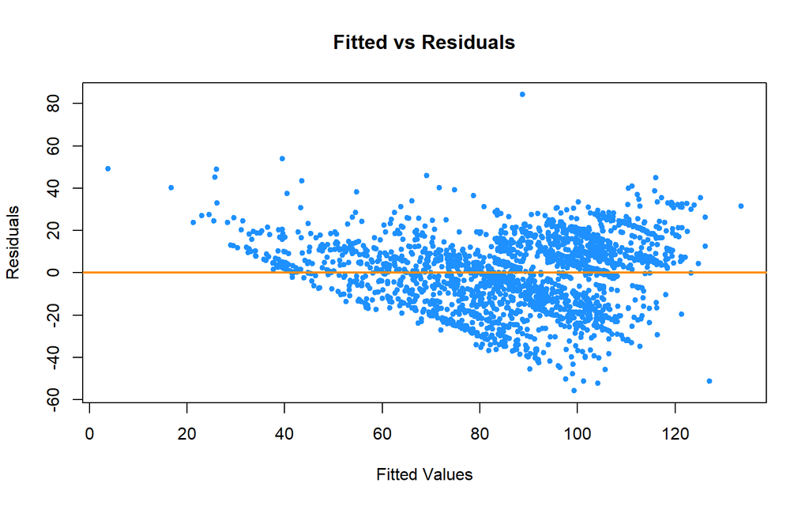

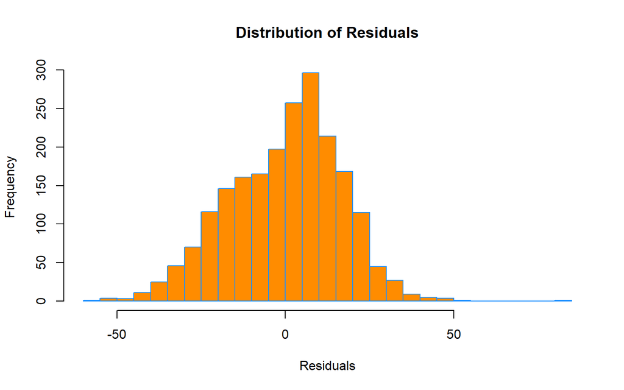

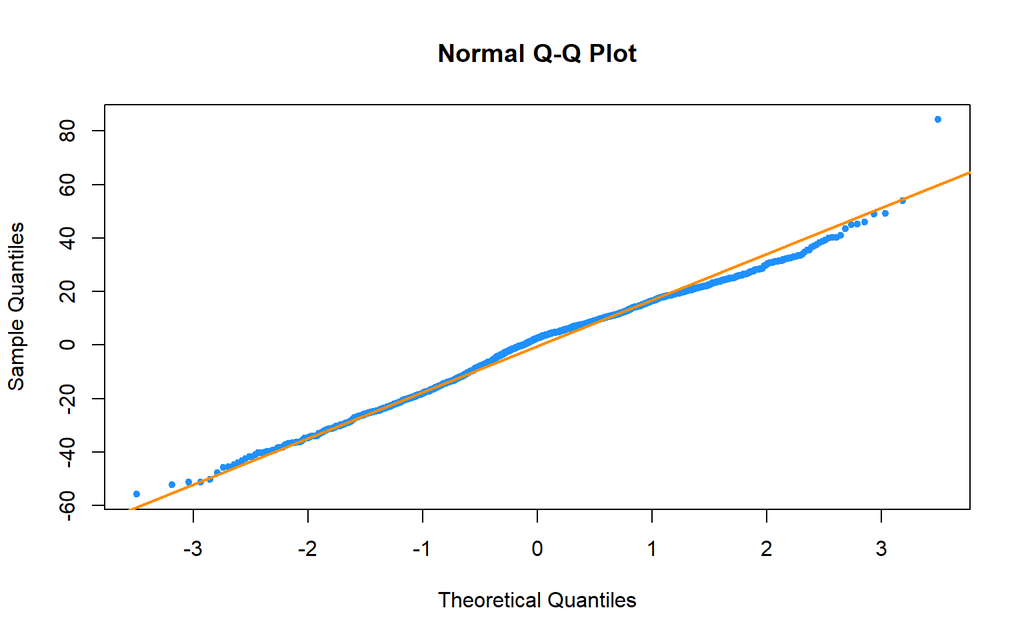

```
## Final Model Assumption Tests:
```

```
## Shapiro-Wilk test p-value: 7.366043e-11
```

```
## Breusch-Pagan test p-value: 1.703283e-49
```

```
##
## VIF values (top 5):
```

```
## [1] 645.30747 602.74511  25.40290  24.55087   4.00000
```

### Influential Observations

```
## Number of potentially influential observations: 85
```

```
##
## Model without top influential points:
## Original Adjusted R-squared: 0.5916482
## Clean Adjusted R-squared: 0.5942934
```

### Cross-Validation of Final Model

```
## 10-Fold Cross-Validation for Final Model:
```

```
## RMSE: 16.81441
```

```
## R-squared: 0.5879523
```

```
## MAE: 13.59807
```

```
##
##
## Comparison with Baseline:
```

```
## Baseline RMSE: 17.0961
```

```
## Final RMSE: 16.81441
```

```
## Improvement: 0.2816959
```

Linearity is reasonably satisfied. Residuals show some departure from normality in the tails and clear heteroscedasticity (Breusch–Pagan p < 0.001). About 4% of points are flagged as influential, but removing the top ones barely changes adjusted R².

### Model Interpretation

```
## Coefficient Estimates:
```

```
##                                       Estimate  Std. Error     t value
## (Intercept)                       -270.3274062 21.35564094 -12.6583607
## Height                             170.0491960  7.86181222  21.6297708
## GenderMale                         149.5390938 17.98940636   8.3126197
## Age                                  0.9950709  0.07882673  12.6235207
## family_history_with_overweightyes   17.7460962  1.10086575  16.1201274
## FAVCyes                              3.8684726  1.25123393   3.0917261
## FCVC                                 8.0189875  0.74370118  10.7825397
## CAECFrequently                      -9.3433198  2.57326030  -3.6309268
## CAECno                               1.2736650  3.67193448   0.3468649
## CAECSometimes                        9.3928316  2.37727599   3.9510901
## CH2O                                 1.5910361  0.64325322   2.4734211
## SCCyes                              -2.8891581  1.85966342  -1.5535919
## FAF                                 -2.7613965  0.47850731  -5.7708555
## TUE                                 -1.7826814  0.65403124  -2.7256824
## CALCFrequently                      -8.4624997 17.07704537  -0.4955482
## CALCno                             -10.6409883 16.97165325  -0.6269860
## CALCSometimes                       -2.7747184 16.98145180  -0.1633970
## MTRANSBike                           3.5740158  6.44437689   0.5545945
## MTRANSMotorbike                     10.8735520  5.17721521   2.1002704
## MTRANSPublic_Transportation         13.5772551  1.15108984  11.7951307
## MTRANSWalking                        4.6110194  2.55959565   1.8014640
## Height:GenderMale                  -90.5690389 10.55520566  -8.5805092
##                                       Pr(>|t|)
## (Intercept)                       2.007302e-35
## Height                            1.093883e-93
## GenderMale                        1.675006e-16
## Age                               3.028581e-35
## family_history_with_overweightyes 3.708066e-55
## FAVCyes                           2.016553e-03
## FCVC                              2.071505e-26
## CAECFrequently                    2.892826e-04
## CAECno                            7.287282e-01
## CAECSometimes                     8.040961e-05
## CH2O                              1.346255e-02
## SCCyes                            1.204350e-01
## FAF                               9.078991e-09
## TUE                               6.471046e-03
## CALCFrequently                    6.202659e-01
## CALCno                            5.307377e-01
## CALCSometimes                     8.702218e-01
## MTRANSBike                        5.792321e-01
## MTRANSMotorbike                   3.582607e-02
## MTRANSPublic_Transportation       4.025470e-31
## MTRANSWalking                     7.177559e-02
## Height:GenderMale                 1.824694e-17
```

- **Age:** For each additional year of age, weight increases by 0.995 kg on average, holding all else constant.
- **Height:** The effect of height on weight depends on gender.
  - **For Females:** Each additional meter increases weight by 170.05 kg on average.
  - **For Males:** Each additional meter increases weight by 79.48 kg on average.
- **Family history:** Having family history of overweight changes weight by 17.75 kg on average.

## 3.3 Concluding Thoughts

### Model Interpretation

Our final multiple linear regression model explains approximately 59.2% of the variance in body weight. The model performs well with a 10-fold cross-validated RMSE of 16.81 kg, indicating reasonable predictive accuracy.

The highly significant F-statistic confirms that our model is significantly better than an intercept-only model. This suggests that the selected lifestyle and demographic factors collectively have meaningful relationships with body weight.

### Key Findings

1. **Height-Gender Interaction**: The significant interaction between height and gender indicates that the relationship between height and weight differs between males and females. Females show a steeper weight increase per unit height compared to males (about 1.7 kg per cm for females vs. 0.79 kg per cm for males).
2. **Physical Characteristics**: Both height and age are significant predictors of weight. Taller individuals and older individuals tend to weigh more.
3. **Lifestyle Factors**: Physical activity frequency (FAF) is negatively associated with weight (about −2.76 kg per unit), while vegetable consumption (FCVC) is positively associated (about +8.02 kg per unit).
4. **Family History**: Family history with overweight is a significant predictor, suggesting genetic or shared environmental factors.
5. **Model Performance**: With an adjusted R-squared of 0.5916, our model explains approximately 59.2% of the variation in weight, which is quite good for a biological/behavioral model.

### Recommendations

1. The model performs well enough for general weight prediction and could be useful for understanding which factors relate to weight.
2. Future improvements could include:
   - Non-linear modeling approaches (Neural Networks, random forests)
   - Additional predictors such as genetic markers or detailed dietary information
   - Geographic and cultural factors beyond the current dataset

# 4. APPENDIX

## 4.1 Important Models

```r
# Fit the full model with all predictors except NObeyesdad
# because it directly relates to weight
full_model <- lm(Weight ~ . - NObeyesdad, data = obesity)
summary(full_model)

# Backward selection using AIC
model_backward_aic <- step(full_model, direction = "backward", trace = 0)
#cat("Backward Selection (AIC) - Variables retained:\n")
#names(coef(model_backward_aic))
get_cv_metrics(formula(model_backward_aic), obesity, "Backward AIC")

# Forward selection
null_model <- lm(Weight ~ 1, data = obesity)
model_forward_aic <- step(null_model,
scope = list(lower = null_model, upper = full_model), direction = "forward", trace = 0)
#cat("\n\nForward Selection (AIC) - Variables selected:\n")
#names(coef(model_forward_aic))
get_cv_metrics(formula(model_forward_aic), obesity, "Forward AIC")

# Both directions
model_both_aic <- step(full_model, direction = "both", trace = 0)
get_cv_metrics(formula(model_both_aic), obesity, "Both-direction AIC")

# BIC
n <- nrow(obesity)
model_backward_bic <- step(full_model, direction = "backward", k = log(n), trace = 0)

#cat("\n\nBackward Selection (BIC) - Variables retained:\n")
#names(coef(model_backward_bic))
get_cv_metrics(formula(model_backward_bic), obesity, "Backward BIC")

# Add polynomial terms for continuous predictors with strong relationships
model_poly <- lm(Weight ~ poly(Height, 2) + poly(Age, 2) + poly(FAF, 2) + Gender +
family_history_with_overweight + FAVC + FCVC + NCP + CAEC + SMOKE + CH2O +
SCC + TUE + CALC + MTRANS, data = obesity)

summary(model_poly)$adj.r.squared

# Test if polynomial terms improve the model
model_height_poly <- lm(Weight ~ Height + I(Height^2) + Age + Gender +
family_history_with_overweight + FAVC + FCVC + NCP +
CAEC + SMOKE + CH2O + SCC + FAF + TUE + CALC +
MTRANS, data = obesity)

anova(model_backward_aic, model_height_poly)

get_cv_metrics(formula(model_poly), obesity, "Polynomial")

# Combine AIC backward selection with best interaction
model_combined <- lm(Weight ~ Height * Gender + Age +
                    family_history_with_overweight + FAVC + FCVC +
                    CAEC + CH2O + SCC + FAF + TUE + CALC + MTRANS,
                    data = obesity)

cat("Combined Model Formula:\n")
print(formula(model_combined))
#summary(model_combined)
summary_combined <- summary(model_combined)

cat("Adjusted R-squared:", summary_combined$adj.r.squared, "\n")
cat("Residual Standard Error:", summary_combined$sigma, "kg\n")
cat("F-statistic:", summary_combined$fstatistic[1], "\n")
cat("Degrees of Freedom:", summary_combined$df[1], "used,",
    summary_combined$df[2], "residual\n")
```

## 4.2 Selected Final Model

```r
# Final selected model
final_model <- lm(Weight ~ Height * Gender + Age +
                    family_history_with_overweight + FAVC + FCVC +
                    CAEC + CH2O + SCC + FAF + TUE + CALC + MTRANS,
                    data = obesity)

summary(final_model)
```

## 4.3 Alternative Final Model

```
## Alternative Model (No Interaction):
```

```
##
## Call:
## lm(formula = Weight ~ Age + Height + Gender + family_history_with_overweight +
##     FAVC + FCVC + CH2O + FAF, data = obesity)
##
## Residuals:
##     Min      1Q  Median      3Q     Max
## -57.712 -12.430   1.914  12.757  64.044
##
## Coefficients:
##                                     Estimate Std. Error t value
## (Intercept)                       -197.56295   10.06581 -19.627
## Age                                  0.52270    0.06804   7.683
## Height                             131.36831    6.33039  20.752
## GenderMale                          -5.60417    1.13870  -4.922
## family_history_with_overweightyes   22.11862    1.19152  18.563
## FAVCyes                              8.91817    1.36450   6.536
## FCVC                                 9.51128    0.82722  11.498
## CH2O                                 2.97613    0.71814   4.144
## FAF                                 -4.23354    0.52948  -7.996
##                                   Pr(>|t|)
## (Intercept)                        < 2e-16 ***
## Age                               2.38e-14 ***
## Height                             < 2e-16 ***
## GenderMale                        9.26e-07 ***
## family_history_with_overweightyes  < 2e-16 ***
## FAVCyes                           7.93e-11 ***
## FCVC                               < 2e-16 ***
## CH2O                              3.55e-05 ***
## FAF                               2.12e-15 ***
## ---
## Signif. codes:  0 '***' 0.001 '**' 0.01 '*' 0.05 '.' 0.1 ' ' 1
##
## Residual standard error: 19.04 on 2078 degrees of freedom
## Multiple R-squared:  0.4737, Adjusted R-squared:  0.4717
## F-statistic: 233.8 on 8 and 2078 DF,  p-value: < 2.2e-16
```

```
##
##
## Comparison with Final Model:
```

```
## Final Model (with interaction):
```

```
##   AIC: 17707.18
```

```
##   Adj R²: 0.5916482
```

```
## Alternative Model (no interaction):
```

```
##   AIC: 18231.95
```

```
##   Adj R²: 0.4716514
```

```
## Nested F-test for interaction term:
```

```
## Analysis of Variance Table
##
## Model 1: Weight ~ Age + Height + Gender + family_history_with_overweight +
##     FAVC + FCVC + CH2O + FAF
## Model 2: Weight ~ Height * Gender + Age + family_history_with_overweight +
##     FAVC + FCVC + CAEC + CH2O + SCC + FAF + TUE + CALC + MTRANS
##   Res.Df    RSS Df Sum of Sq      F    Pr(>F)
## 1   2078 753122
## 2   2065 578434 13    174688 47.972 < 2.2e-16 ***
## ---
## Signif. codes:  0 '***' 0.001 '**' 0.01 '*' 0.05 '.' 0.1 ' ' 1
```

## 4.4 Coefficient Confidence Intervals

```r
# 95% Confidence intervals for final model coefficients
ci_final <- confint(final_model)
significant_coefs <- summary(final_model)$coefficients[, "Pr(>|t|)"] < 0.05

cat("Significant Coefficients (p < 0.05) with 95% CI:\n\n")
for(i in which(significant_coefs)) {
  coef_name <- names(coef(final_model))[i]
  cat(sprintf("%-30s: %7.4f [%7.4f, %7.4f]\n",
              coef_name,
              coef(final_model)[i],
              ci_final[i, 1],
              ci_final[i, 2]))
}
```

[output not shown]

**End of Report**